# **Data overview**

# **Data cleaning**

- Drop/remove redundant features from the dataset that might create noise when modeling.

```python
# Remove redundant features
print('Performing data cleaning (drop redundant features):')
df_cleaned = df_dum_con.drop(['Unique ID', 'Product ID'], axis=1)
# Drop 'Quality' column
df_cleaned = df_cleaned.drop(['Quality'], axis=1)
# Preview first 5 rows to confirm
df_cleaned.head()
```

```
Performing data cleaning (drop redundant features):
```

|  | Ambient T (C) | Process T (C) | Rotation Speed (rpm) | Torque (Nm) | Tool Wear (min) | Machine Status | Quality_L | Quality_M |
| --- | --- | --- | --- | --- | --- | --- | --- | --- |
| 0 | 24.95 | 35.45 | 1551.0 | 42.8 | 0 | 0 | False | True |
| 1 | 25.05 | 35.55 | 1408.0 | 46.3 | 3 | 0 | True | False |
| 2 | 24.95 | 35.35 | 1498.0 | 49.4 | 5 | 0 | True | False |
| 3 | 25.05 | 35.45 | 1433.0 | 39.5 | 7 | 0 | True | False |
| 4 | 25.05 | 35.55 | 1408.0 | 40.0 | 9 | 0 | True | False |

- Use heatmap to find the high correlated features.
- 0.80 and above are considered highly correlated.
- 'Ambient T (C)' and 'Torque (Nm)' are above 0.80.

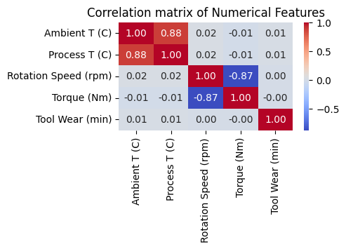

```python
# Heatmap
corr_matrix = df_cleaned[['Ambient T (C)', 'Process T (C)', 'Rotation Speed (rpm)', 'Torque (Nm)', 'Tool Wear (min)']].corr()
plt.figure(figsize=(4, 2))
sns.heatmap(corr_matrix, annot=True, cmap='coolwarm', fmt=".2f")
plt.title('Correlation matrix of Numerical Features')
plt.show()
```

- Drop 'Ambient T (C)' and 'Torque (Nm)' columns as they are above 0.80 above

```python
# Remove correlated features from the dataset that might create noise when modeling
print('Data cleaning (drop correlated features):')
df_cleaned = df_cleaned.drop(['Ambient T (C)', 'Torque (Nm)'], axis=1) # 'Ambient T (C)' is 0.88 & 'Torque (Nm)' is -0.88
# Preview first 5 rows to confirm
df_cleaned.head()
```

```
Data cleaning (drop correlated features):
```

|  | Process T (C) | Rotation Speed (rpm) | Tool Wear (min) | Machine Status | Quality_L | Quality_M |
| --- | --- | --- | --- | --- | --- | --- |
| 0 | 35.45 | 1551.0 | 0 | 0 | False | True |
| 1 | 35.55 | 1408.0 | 3 | 0 | True | False |
| 2 | 35.35 | 1498.0 | 5 | 0 | True | False |
| 3 | 35.45 | 1433.0 | 7 | 0 | True | False |
| 4 | 35.55 | 1408.0 | 9 | 0 | True | False |

- Convert data type of boolean to int because scikit-learn only can accept numerical and boolean data types.

```python
# Convert data type of 'Quality_L' & 'Quality_M' from boolean to int for imputation purpose
df_cleaned[['Quality_L','Quality_M']] = df_cleaned[['Quality_L','Quality_M']].astype(int)
# Check data type after conversion
df_cleaned.info()
```

```
<class 'pandas.core.frame.DataFrame'>
RangeIndex: 20000 entries, 0 to 19999
Data columns (total 6 columns):
 #   Column                Non-Null Count  Dtype
---  ------                --------------  -----
 0   Process T (C)         19600 non-null  float64
 1   Rotation Speed (rpm)  18812 non-null  float64
 2   Tool Wear (min)       20000 non-null  int64
 3   Machine Status        20000 non-null  int64
 4   Quality_L             20000 non-null  int64
 5   Quality_M             20000 non-null  int64
dtypes: float64(2), int64(4)
memory usage: 937.6 KB
```

**Preprocessing**

- Create pipelines for 2 reasons below:
- imputation: replace the missing values
- standardization: big range in numerical features

```python
from sklearn.impute import SimpleImputer
from sklearn.preprocessing import StandardScaler, OneHotEncoder
from sklearn.compose import ColumnTransformer
from sklearn.pipeline import Pipeline
from sklearn.neighbors import KNeighborsClassifier
from sklearn.linear_model import LogisticRegression
from sklearn.tree import DecisionTreeClassifier

# Create preprocessing pipelines
mean_standardscaler_pipeline = Pipeline(steps=[
    ('imputer_mean', SimpleImputer(strategy='mean')), # replace missing data & feature's distribution is relatively symmetric and not heavily skewed by outliers.
    ('normalizer', StandardScaler())
])

median_standardscaler_pipeline = Pipeline(steps=[
    ('imputer_median', SimpleImputer(strategy='median')), # replace missing data & more robust to outliers
    ('normalizer', StandardScaler())
])

standardscaler_pipeline = Pipeline(steps=[
    ('normalizer', StandardScaler())
])

most_frequent_pipeline = Pipeline(steps=[
    ('imputer', SimpleImputer(strategy='most_frequent')) # replace missing data
])


# Use ColumnTransformer to apply preprocessing pipelines to the correct columns
preprocessor = ColumnTransformer(
    transformers=[
        ('num_mean_standardscaler_transform', mean_standardscaler_pipeline, ['Process T (C)']),
        ('num_median_standardscaler_transform', median_standardscaler_pipeline, ['Rotation Speed (rpm)']),
        ('num_standardscaler_transform', standardscaler_pipeline, ['Tool Wear (min)']),
        ('cat_most_frequent_transform', most_frequent_pipeline, ['Quality_L', 'Quality_M'])
    ],
    remainder='drop' # Any columns in dataset that are not explicitly mentioned in the transformers list will be dropped.
)

# Integrate into a full pipeline with K-Nearest Neighbors (KNN) model
# Using n_neighbors=6 as per your first snippet.
knn_full_pipeline = Pipeline(steps=[
    ('preprocessor', preprocessor),
    ('knn_classifier', KNeighborsClassifier())
])

# Integrate into a full pipeline with Logistic Regression model
lr_full_pipeline = Pipeline(steps=[
    ('preprocessor', preprocessor),
    ('logistic_regression', LogisticRegression())
])

# Integrate into a full pipeline with Decision Tree Classifier/Classification and Regression Trees (CART) model
dtc_full_pipeline = Pipeline(steps=[
    ('preprocessor', preprocessor),
    ('decision_tree_classifier', DecisionTreeClassifier())
])
```

**Spliting the data**

- Define features (X) for and target (y)
- - X is features without machine status
- - y is machine status
- The prediction task is to classify the machine status.

```python
# Define features (X) and target (y)
X = df_cleaned.drop('Machine Status', axis=1)
y = df_cleaned['Machine Status']
```

- Split the data into 80% for training set and 20% for testing set before taining and testing to prevent data leakage.

```python
from sklearn.model_selection import train_test_split

X_train, X_test, y_train, y_test = train_test_split(X, y, test_size=0.2, random_state=42, stratify=y) # 'stratify=y' is used here because class 1) is much rarer than class 0 (imbalanced data)
print('Check the shape of train and test datasets after spliting')
print(f'X shape: {X.shape}')
print(f'X_train shape: {X_train.shape}')
print(f'X_test shape: {X_test.shape}')
```

```
Check the shape of train and test datasets after spliting
X shape: (20000, 5)
X_train shape: (16000, 5)
X_test shape: (4000, 5)
```

**Evaluating classification models**